# p8105_hw5_bl2689

Boxuan Li

10/31/2017

## Problem 1

*Read the dataset and tidy it.*

```r
Subway.ny <- GET("https://data.ny.gov/resource/hvwh-qtfg.json",
                 query = list(`$limit` = 2000)) %>%
  content("text") %>%
  jsonlite::fromJSON() %>%
  select(., station_name, entrance_latitude, entrance_longitude, east_west_street, north_south_street, corner) %>%
  as_tibble() %>%
  clean_names()

Subway.ny
```

```
## # A tibble: 1,868 x 6
##    station_name entrance_latitude entrance_longitude east_west_street
##  *        <chr>             <chr>              <chr>            <chr>
##  1      25th St         40.660323         -73.997952          25th St
##  2      25th St         40.660489         -73.998220          25th St
##  3      36th St         40.654490         -74.004499          36th St
##  4      36th St         40.654365         -74.004113          36th St
##  5      36th St         40.654676         -74.004306          36th St
##  6      45th St         40.649389         -74.009333          45th St
##  7      45th St         40.649424         -74.009728          45th St
##  8      45th St         40.649265         -74.009457          45th St
##  9      45th St         40.649546         -74.009602          45th St
## 10      53rd St         40.644653         -74.014690          53rd St
## # ... with 1,858 more rows, and 2 more variables:
## #   north_south_street <chr>, corner <chr>
```

*Make a plot on the number of entrances.*

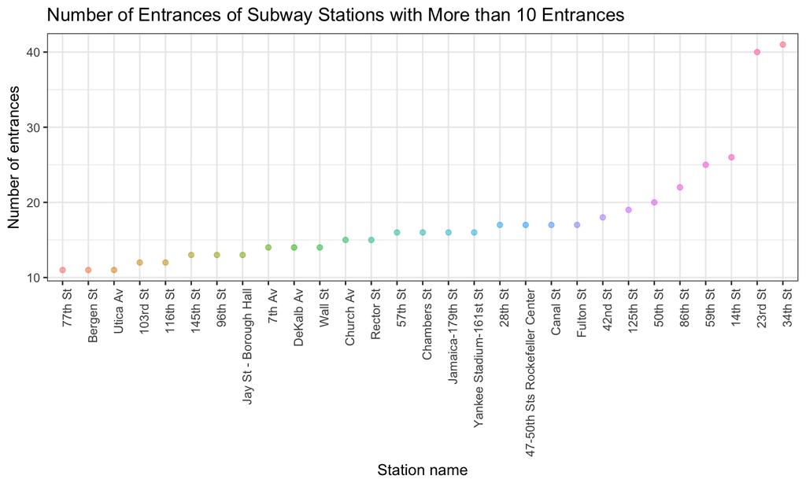

```r
Subway.ny %>%
  group_by(., station_name) %>%
  summarize(., no_entrances = n()) %>%
  filter(., no_entrances > 10) %>%
  mutate(., station_name = fct_reorder(station_name, no_entrances)) %>%
  ggplot(., aes(x = station_name, y = no_entrances, color = station_name)) +
  geom_point(alpha = 0.5) +
  theme(axis.text.x = element_text(angle = 90, hjust = 1), legend.position='none') +
  labs(title = "Number of Entrances of Subway Stations with More than 10 Entrances",
       x = "Station name",
       y = "Number of entrances")
```

*Check the station name with “St”.*

```r
Stations.wt.St <- Subway.ny %>%
  filter(., str_detect(station_name, "St"))

No.stations <- length(unique(Stations.wt.St$station_name))

Stations.end.St <- Stations.wt.St %>%
  mutate(., station_name_end = str_sub(station_name, -2, -1)) %>%
  filter(., station_name_end == "St")

No.stations.end <- length(unique(Stations.end.St$station_name))
```

- Overall, there are 176 station names containing the abbreviation “St”, among which there are 148 station names ending with “St”.

## Problem 2

*Read the dataset and tidy it.*

```r
url.GOT <- "https://en.wikipedia.org/wiki/Game_of_Thrones"
GOT_viewer_xml <- read_html(url.GOT)

GOT_viewers <- html_nodes(GOT_viewer_xml,css = "table")[[4]] %>%
  html_table()

GOT_viewers <- GOT_viewers[,-1] %>%
  select(., everything(), -Average) %>%
  gather(., key = episode, value = viewers, "Ep. 1":"Ep. 10") %>%
  as.tibble() %>%
  clean_names() %>%
  filter(., viewers != "N/A") %>%
  mutate(., viewers = as.numeric(viewers), episode = str_sub(episode, 5, -1)) %>%
  mutate(., episode = as.numeric(episode)) %>%
  mutate(., episode = str_c("S", season, "E", episode))

GOT_viewers
```

```
## # A tibble: 67 x 3
##    season episode viewers
##     <int>   <chr>   <dbl>
##  1      1    S1E1    2.22
##  2      2    S2E1    3.86
##  3      3    S3E1    4.37
##  4      4    S4E1    6.64
##  5      5    S5E1    8.00
##  6      6    S6E1    7.94
##  7      7    S7E1   10.11
##  8      1    S1E2    2.20
##  9      2    S2E2    3.76
## 10      3    S3E2    4.27
## # ... with 57 more rows
```

*Make a boxplot of the number of viewers for episodes of each season.*

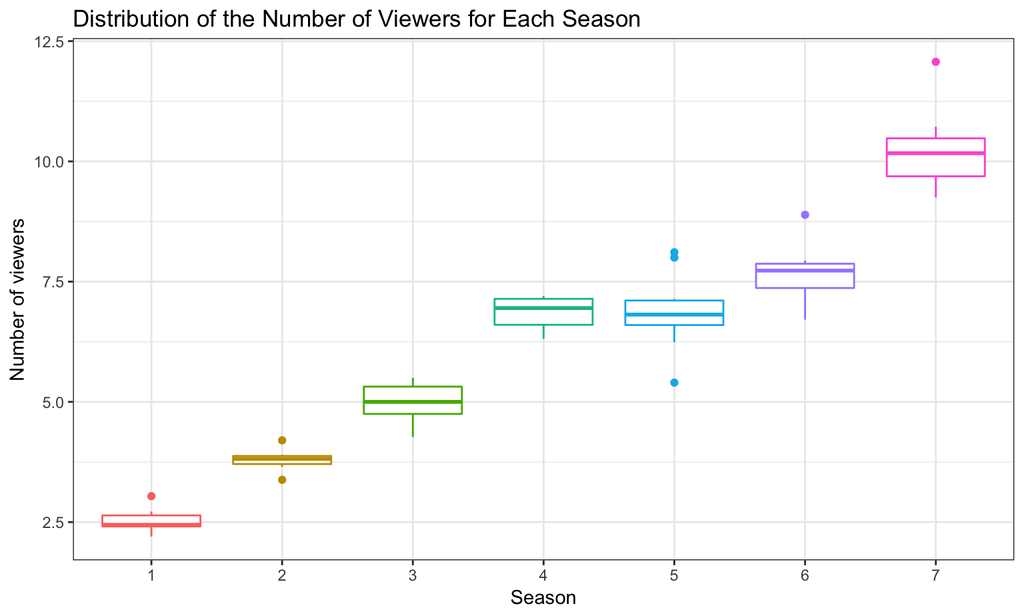

```r
GOT_viewers %>%
  mutate(., season = as.factor(season)) %>%
  ggplot(aes(x = season, y = viewers, color = season)) +
  geom_boxplot() +
  labs(title = "Distribution of the Number of Viewers for Each Season",
       x = "Season",
       y = "Number of viewers") +
  theme(legend.position='none')
```

*Fit a linear model.*

```r
GOT_viewers %>%
  mutate(., season = as.factor(season)) %>%
  mutate(., season = relevel(season, "4")) %>%
  lm(viewers~season, .) %>%
  broom::tidy() %>%
  select(-std.error, -statistic) %>%
  knitr::kable(digits = 3)
```

| term | estimate | p.value |
| --- | --- | --- |
| (Intercept) | 6.846 | 0.000 |
| season1 | -4.331 | 0.000 |
| season2 | -3.051 | 0.000 |
| season3 | -1.880 | 0.000 |
| season5 | 0.034 | 0.889 |
| season6 | 0.842 | 0.001 |
| season7 | 3.415 | 0.000 |

**By fitting the number of viewers into the linear regression model with the season as a categorical predictor and season 4 as the reference, it can be discovered that almost each number of viewers for each season is well fitted in the linear model except for the season 5, which has a large p-value of 0.889. Therefore, it can be concluded that the number of viewers and the season probably have linear relationship.**

## Problem 3

*Read the dataset.*

```r
read_page_reviews <- function(url) {

  h <- read_html(url)

  title <- h %>%
    html_nodes("#cm_cr-review_list .review-title") %>%
    html_text()

  stars <- h %>%
    html_nodes("#cm_cr-review_list .review-rating") %>%
    html_text() %>%
    str_extract("\\d") %>%
    as.numeric()

  text = h %>%
    html_nodes(".review-data:nth-child(4)") %>%
    html_text()

  data_frame(title, stars, text)
}

url_base <- "https://www.amazon.com/product-reviews/B00005JNBQ/ref=cm_cr_arp_d_viewopt_rvwer?ie=UTF8&reviewerType=avp_only_reviews&sortBy=recent&pageNumber="
urls <- paste0(url_base, 1:100)

dynamite_reviews <- map(urls, ~read_page_reviews(.x)) %>%
  bind_rows
```

- In the dataset, there are three variables, be it “title, stars, text” included.
- The scraping is successful because it contains the full reviews with both rating and texts. And the dataset is clean with sufficient information for analysis.

*Create a tidy text dataset using words as the token and remove stop words.*

```r
Dynamite_words <- dynamite_reviews %>%
  unnest_tokens(word, text)

data("stop_words")

Dynamite_words <- anti_join(Dynamite_words, stop_words)

Dynamite_words
```

```
## # A tibble: 6,824 x 3
##                                                title stars    word
##                                                <chr> <dbl>   <chr>
##  1                                        Five Stars     5   brand
##  2                                        Five Stars     5   happy
##  3                                        Five Stars     5 classic
##  4                                        Five Stars     5  comedy
##  5 It doesn't get any better than Napoleon Dynamite!     5   movie
##  6 It doesn't get any better than Napoleon Dynamite!     5  quirky
##  7 It doesn't get any better than Napoleon Dynamite!     5   funny
##  8 It doesn't get any better than Napoleon Dynamite!     5 watched
##  9 It doesn't get any better than Napoleon Dynamite!     5     100
## 10 It doesn't get any better than Napoleon Dynamite!     5   times
## # ... with 6,814 more rows
```

*Check the frequency of words that are used in five-star reviews and 1-star reviews.*

```r
Word_used <- Dynamite_words %>%
  filter(., stars == 1|stars == 5) %>%
  group_by(., stars) %>%
  count(., word, sort = T) %>%
  select(., word, stars, n) %>%
  ungroup()

Word_fivestars <- Word_used %>%
  filter(., stars == 5)

top_n(Word_fivestars, 10)
```

```
## # A tibble: 10 x 3
##         word stars     n
##        <chr> <dbl> <int>
##  1     movie     5   440
##  2      love     5   142
##  3     funny     5   134
##  4   classic     5   115
##  5     watch     5   101
##  6      time     5    88
##  7  napoleon     5    61
##  8    movies     5    54
##  9  favorite     5    50
## 10 hilarious     5    49
```

```r
Word_onestar <- Word_used %>%
  filter(., stars == 1)

top_n(Word_onestar, 10)
```

```
## # A tibble: 12 x 3
##       word stars     n
##      <chr> <dbl> <int>
##  1   movie     1    51
##  2     dvd     1    12
##  3   watch     1    11
##  4    time     1    10
##  5     bad     1     8
##  6    dumb     1     8
##  7   funny     1     7
##  8     blu     1     6
##  9 friends     1     6
## 10    play     1     6
## 11     ray     1     6
## 12 watched     1     6
```

- Therefore, in five-star reviews, “movie, love, funny, classic, watch, time, napoleon, movies, favorite, hilarious” are most frequently used while “movie, dvd, watch, time, bad, dumb, funny, blu, friends, play” are most commonly used in one-star reviews.

*Make a plot that shows the (approximate) log odds ratio for word appearance.*

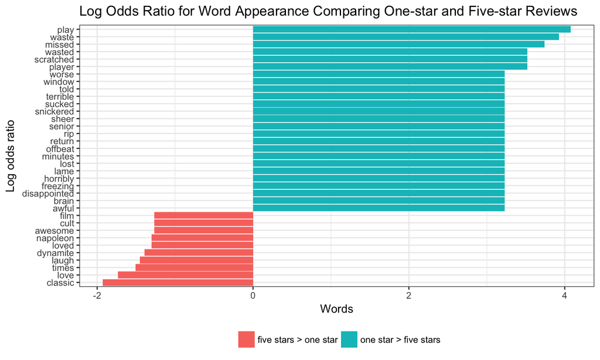

```r
Word_ratio <- Word_used %>%
  spread(., key = stars, value = n, fill = 0) %>%
  select(., word, one_star = "1", five_stars = "5") %>%
  mutate(onestar_odds = (one_star + 1) / (sum(one_star) + 1),
         fivestars_odds = (five_stars + 1) / (sum(five_stars) + 1),
         log_OR = log(onestar_odds / fivestars_odds)) %>%
  arrange(desc(log_OR))

Word_ratio %>%
  mutate(pos_log_OR = ifelse(log_OR > 0, "one star > five stars", "five stars > one star")) %>%
  group_by(., pos_log_OR) %>%
  top_n(., 10, abs(log_OR)) %>%
  ungroup() %>%
  mutate(., word = fct_reorder(word, log_OR)) %>%
  ggplot(., aes(x = word, y = log_OR, fill = pos_log_OR)) +
  geom_col() +
  coord_flip() +
  labs(title = "Log Odds Ratio for Word Appearance Comparing One-star and Five-star Reviews",
       x = "Log odds ratio",
       y = "Words") +
  scale_fill_discrete(name = "")
```

*Sentiment analysis.*

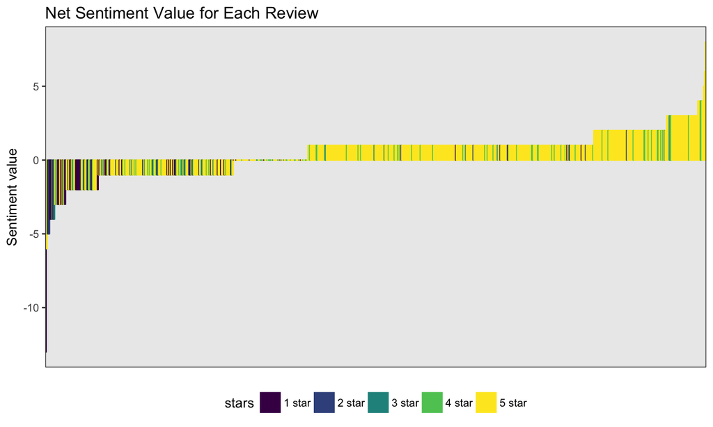

```r
Sentiment <- get_sentiments("bing")

dynamite_reviews2 <- as.data.frame(cbind(1:1000,dynamite_reviews)) %>%
  select(., "1:1000", stars, text)
colnames(dynamite_reviews2)[1] <- "review"

Dynamite_words2 <- dynamite_reviews2 %>%
  unnest_tokens(word, text) %>%
  anti_join(., stop_words)

Word_sentiment <- inner_join(Dynamite_words2, Sentiment) %>%
  group_by(., review, stars) %>%
  count(., review, sentiment) %>%
  spread(., key = sentiment, value = n, fill = 0) %>%
  mutate(., sentiment = positive - negative) %>%
  ungroup() %>%
  select(., review, stars, sentiment) %>%
  arrange(., sentiment)

Best_review <- Word_sentiment$review[dim(Word_sentiment)[1]]
Worst_review <- Word_sentiment$review[1]

Word_sentiment <- mutate(Word_sentiment, review = as.factor(review),
                                         review = fct_reorder(review,sentiment),
                                         stars = paste(stars,"star"))

ggplot(Word_sentiment, aes(x = review, y = sentiment, fill = stars, color = stars)) +
  geom_bar(stat = "identity") +
  theme(axis.title.x = element_blank(),
        axis.text.x = element_blank(),
        axis.ticks.x = element_blank()) +
  scale_fill_viridis(discrete = TRUE) +
  scale_color_viridis(discrete = TRUE) +
  labs(title = "Net Sentiment Value for Each Review",
       x = "Review number",
       y = "Sentiment value")
```

- The most positive review is “Love, love and love! My children ages 13, 10 and 8 enjoy family movie nights and my husband and I were looking for something that we all could enjoy. This movie was perfect! So much fun and beyond quotable comments. A fun family film!” while the most negative review is “Let me start by openly admitting that I am an 80’s throwback and proud of it. I understand that my era did not produce horribly intelligent, deeply touching movies. That being said, this movie puts the Du-h! in Dumb!! My teenage daughter had seen it a sleepover, so we rented it so she could show me how silly it is for our girly night. She actually got tickled at a few spots on her second run through it. I sat open mouthed, amazed at the sheer senselessness of the whole thing…waiting desperately for a plot or growth of a character. None came. Since we had it rented for the weekend, she showed it to her older brother the next night. She giggled again, and he snickered with a confused look on his face once in a while. Then we couldn’t let my Hubby miss out on the sheer stupidity of it all, so we watched it with him on Sunday afternoon. Our daughter and son both snickered here and there, mostly at the looks on their parents’ faces. My husband was, as was I, gobsmackered. We kept looking at each other as if to assure each other that it was indeed that painfully dumb. The only real emotion I felt was a horribly heartbroken, sick to my stomach feeling for Napoleon and his friends for being so awkward and socially inept…I remember kids who struggled in school that way, and I always almost cried every time I saw them in a tough situation. If anything it brought back bad memories of school….who needs that? Anyway, all this to say it is a story about an awkward boy who uses bluster and dumb responses to deal with not fitting in. It follows (if you can exaggerate and say there is a plot) him as he finds friends (just as goofy as he) and finds romance…sort of.”.